# Practica 2

Murillo Alba Josué Iván

Febrero 2025

```r
library(dplyr)
# Generar el ruido blanco
v <- ts(sample(0:1,100, replace =TRUE)*2-1)
v
```

```
## Time Series:
## Start = 1
## End = 100
## Frequency = 1
##   [1] -1  1 -1 -1  1 -1  1  1  1 -1  1  1 -1 -1 -1  1 -1  1 -1 -1 -1 -1  1  1 -1
##  [26] -1 -1  1  1 -1  1 -1 -1 -1 -1 -1  1 -1 -1  1  1  1  1  1  1  1  1 -1 -1  1
##  [51] -1 -1 -1 -1  1 -1  1  1  1  1  1  1 -1 -1 -1  1 -1  1 -1  1  1 -1 -1  1  1
##  [76]  1 -1 -1  1  1 -1 -1 -1  1 -1  1  1  1 -1  1 -1 -1 -1 -1  1 -1 -1  1  1  1
```

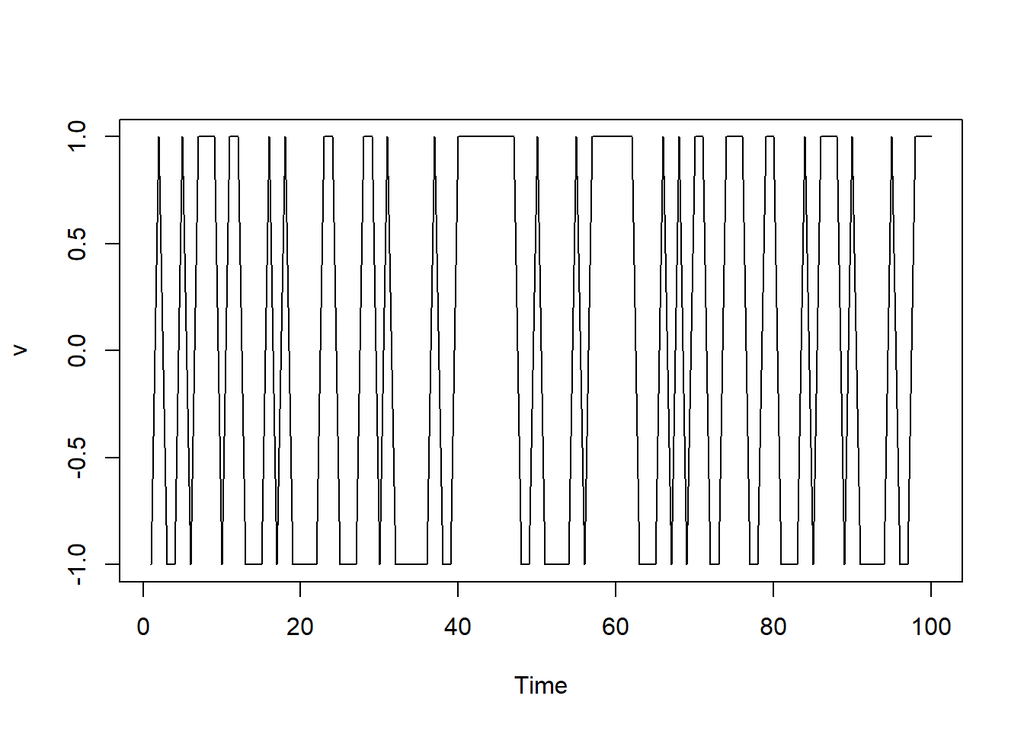

```r
plot(v)
```

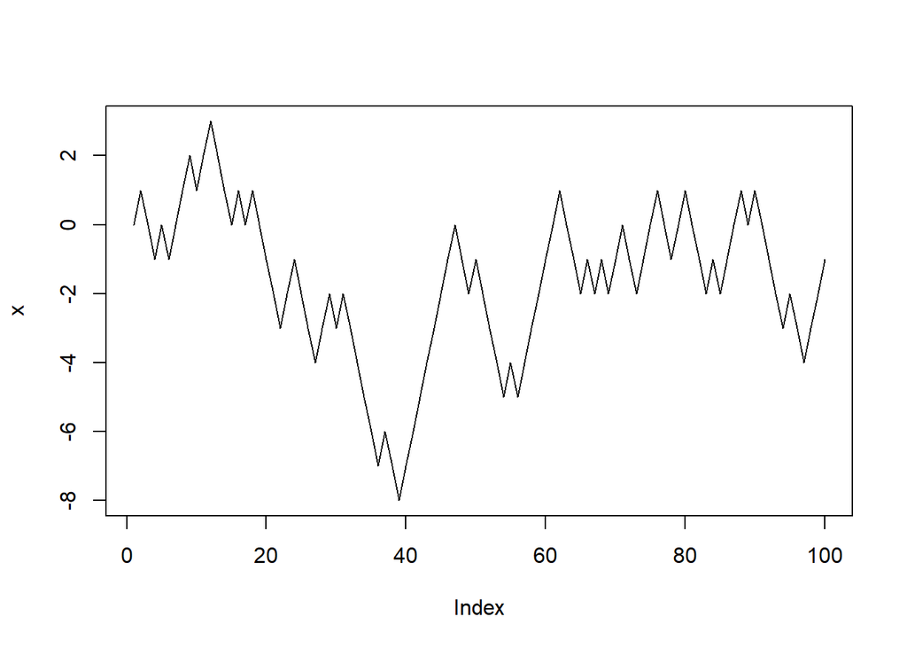

```r
# Caminata Aletoria
x<-numeric(100)
for (t in 2:100) {
  x[t]<-x[t-1]+v[t]

}

plot(x, type = 'l')
```

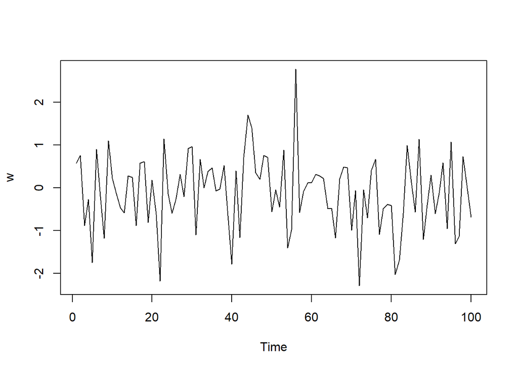

```r
# Ruido blanco
w<-ts(rnorm(100))

plot(w)
```

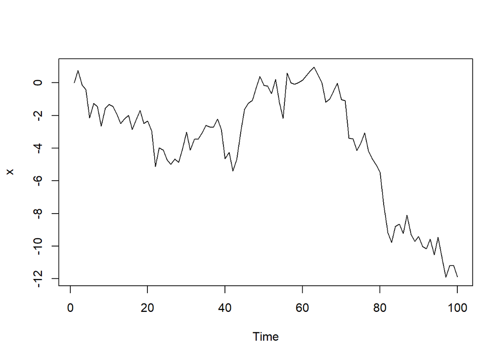

```r
# Caminata aleatoria
x <- ts(numeric(100))
for(t in 2:100)
  x[t]<-x[t-1] + w[t]

plot(x)
```

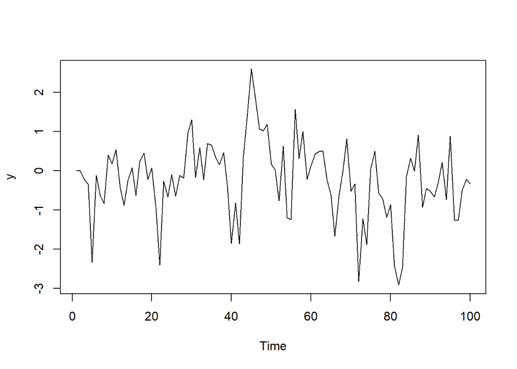

```r
# MA
y <- ts(numeric(100))
for (t in 3:100)
  y[t]<-1/2*w[t-1]+1/2*w[t-2]+w[t]

plot(y)
```

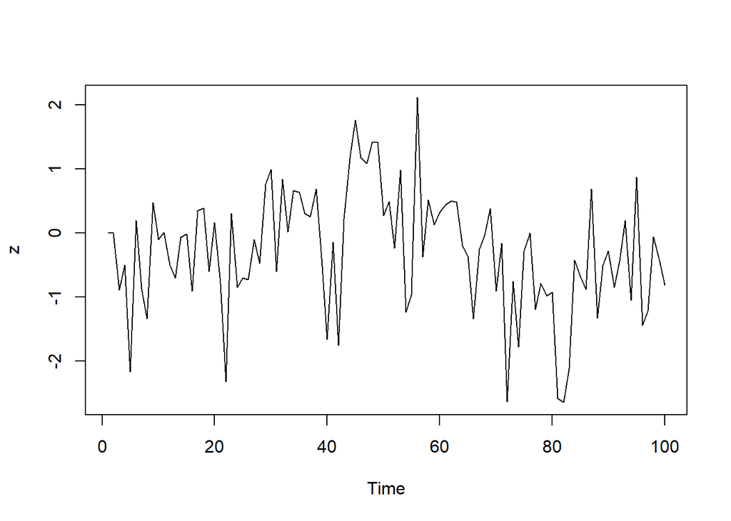

```r
# Autoregresivo

z <- ts(numeric(100))
for (t in 3:100)
  z[t]<-1/4*z[t-1]+1/3*z[t-2]+w[t]

plot(z)
```

Sea {Wt} un proceso de ruido blanco i.i.d. N(0, 1). Varianza σ 2 = 1. Considera los procesos estocásticos en los incisos. 1. Realiza una gráfica con los primeros 100 valores. 2. Identifica cada proceso estocástico y escribe su nombre. 3. Realiza una gráfica con los primeros 1000 valores. 4. Calcula la media de una serie de tiempo con 1000 valores, de cada proceso estocástico, usando R (mean(Xt)). 5. Calcula algebraicamente el valor esperado para los incisos a), b) y c). 6. Determina si la parte homogénea de los procesos estocásticos es convergente o explosiva. 7. Calcula las covarianzas cov(Xt , Xt−1), cov(Xt , Xt−4) de los procesos estocásticos

# A

1. Xt = Wt

## 1

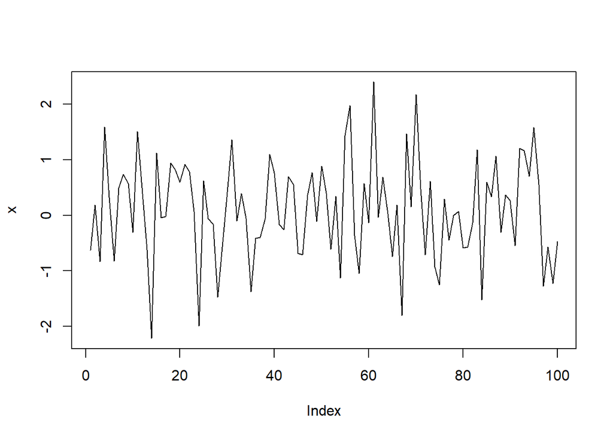

```r
set.seed(1)
w <-ts(rnorm(100))

x <- numeric(100)
for (t in 1:100) {
  x[t]<- w[t]

}
plot(x, type = 'l')
```

## 2

Es un proceso estocastico de ruido blanco ya que el valor actual depende de un valores que son independientes y que tienen una distribucion identica a lo largo del tiempo con media 0 e igual varianza

## 3

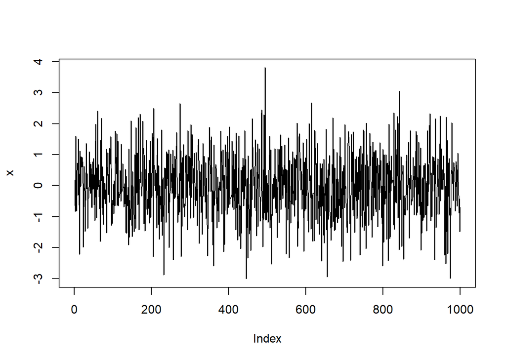

```r
set.seed(1)
w <-ts(rnorm(1000))

x <- numeric(1000)
for (t in 1:1000) {
  x[t]<- w[t]

}
plot(x, type = 'l')
```

## 4

```r
set.seed(1)
w <-ts(rnorm(1000))

x <- numeric(1000)

mean(w)
```

```
## [1] -0.01164814
```

## 5

El valor esperado (media) de $X_t$ es simplemente la esperanza de $W_t$:

$$E[X_t] = E[W_t]$$

Por definición del proceso,

$$E[W_t] = 0$$

Por lo tanto:

$$E[X_t] = 0$$

En un proceso de ruido blanco i.i.d., cada $W_t$ es independiente de los demás y sigue una distribución normal con media $0$. Esto implica que:
$$E[W_t] = 0 \quad \text{para todo } t.$$
Independencia del Tiempo

La media de $X_t = W_t$ no depende de $t$, ya que todas las $W_t$ son idénticamente distribuidas.

## 6

Razones por las que no aplica

No hay componente homogénea

La ecuación $X_t = W_t$ no contiene términos autorregresivos (como $X_{t-1}, X_{t-2}$, etc.). Por lo tanto, no hay una “parte homogénea” asociada al proceso. La ecuación es puramente no homogénea (depende solo del ruido $W_t$).

Estructura del modelo

Ecuación general: $X_t =$ Componente homogénea + Componente no homogénea (ruido)

En este caso: $X_t = 0 + W_t$

No hay términos en $X_{t-k}$, por lo que la parte homogénea es trivialmente nula.

## 7

Propiedades de {W_t}
$$E[W_t] = 0$$

$$\text{Var}(W_t) = 1$$

$$\text{Cov}(W_t, W_{t-h}) = 0 \quad \text{para } h \neq 0$$

Covarianzas

$$\text{Cov}(X_t, X_{t-1}) = \text{Cov}(W_t, W_{t-1}) = 0$$

# B

Xt = Xt−1 + Wt , con X1 = 0

## 1

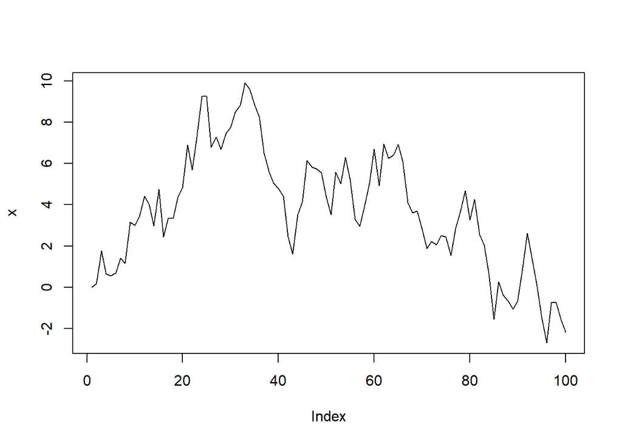

```r
set.seed(2)
w <-ts(rnorm(100))

x <- numeric(100)
x[1] <- 0
for (t in 2:100) {
  x[t]<- x[t-1] + w[t]

}
plot(x, type = 'l')
```

## 2

Caminata aleatoria: el pronostico actual es igual al pronostico anterior mas cercano y un error o ruido blanco

## 3

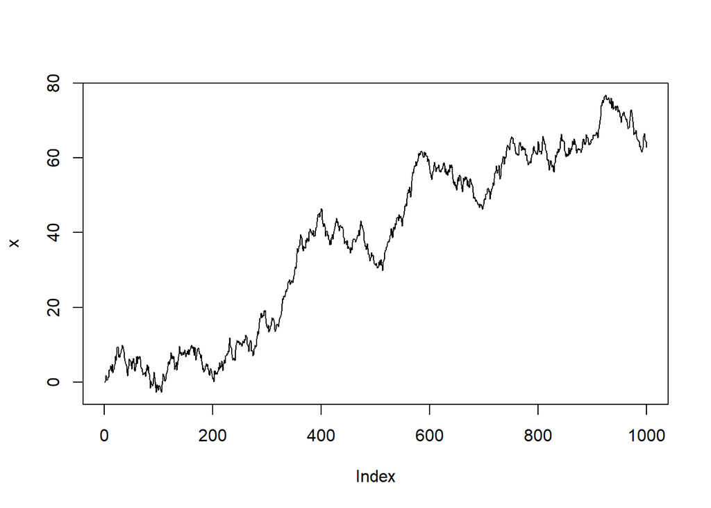

```r
set.seed(2)
w <-ts(rnorm(1000))

x <- numeric(1000)
x[1] <- 0
for (t in 2:1000) {
  x[t]<-x[t-1] + w[t]

}
plot(x, type = 'l')
```

## 4

```r
set.seed(2)
w <- rnorm(1000)

x <- numeric(1000)
x[1] <- 0

for (t in 2:1000) {
  x[t] <- x[t-1] + w[t]
}

media_x <- mean(x)
print(media_x)
```

```
## [1] 37.83343
```

## 5

Valor Esperado de $X_t$

El valor esperado de $X_t$ es cero para todo $t \geq 1$, independientemente del tiempo. Esto ocurre porque el proceso es una caminata aleatoria sin deriva (no hay término constante), y los choques aleatorios $W_t$ tienen media cero.

$$E[X_t] = 0 \quad \text{para todo } t \geq 1$$

## 6

Raíz unitaria: Procesos no estacionarios con varianza creciente

## 7

cov (xt, xt-1)= t-2 cov (xt, xt-4)= t-5

# C

3. Xt =1/2Wt−3 −1/3Wt−2 −1/4Wt−1 + Wt , con X1 = 0, X2 = 0, X3 = 0

## 1

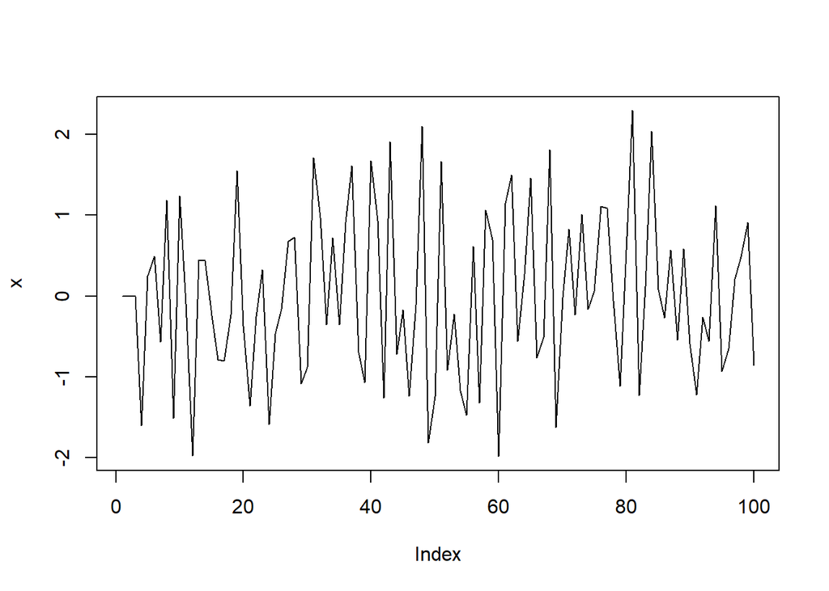

```r
set.seed(3)
w <- rnorm(100)

x <- numeric(100)
x[1] <- 0
x[2] <- 0
x[3] <- 0
for (t in 4:100) {
  x[t]<- (1/2)*w[t-3]-(1/3)*w[t-2]-(1/4)*w[t-1]+w[t]

}
plot(x, type = 'l')
```

## 2

Es de termino de Moving Average de orden 3: el momento actual depende de ruido blanco de momentos anteriores

## 3

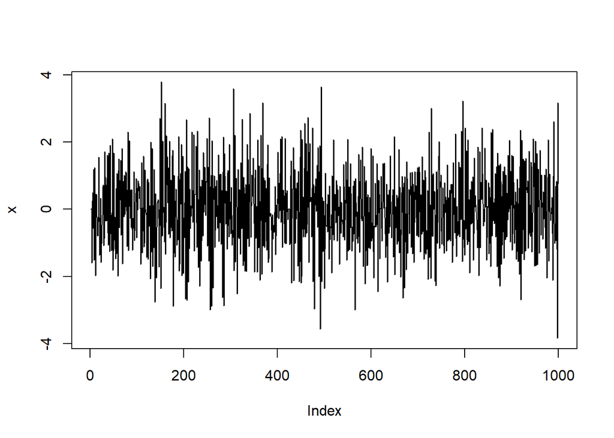

```r
set.seed(3)
w <- rnorm(1000)

x <- numeric(1000)
x[1] <- 0
x[2] <- 0
x[3] <- 0
for (t in 4:1000)
  x[t]<- (1/2)*w[t-3]-(1/3)*w[t-2]-(1/4)*w[t-1]+ w[t]
plot(x, type = 'l')
```

## 4

```r
set.seed(3)
w <- rnorm(1000)

x <- numeric(1000)
x[1] <- 0
x[2] <- 0
x[3] <- 0
for (t in 4:1000)
  x[t]<- (1/2)*w[t-3]-(1/3)*w[t-2]-(1/4)*w[t-1]+w[t]


mean(x)
```

```
## [1] 0.007571122
```

## 5

La esperanza es 0 ya que esta conformado por ruido blanco y la esperanza del ruido blanco es 0

## 6

Estacionariedad: Los modelos MA son siempre estacionarios (en covarianza), ya que son combinaciones lineales finitas de términos de ruido blanco.

La estacionariedad no depende de los coeficientes θi

MA no contienen parte homogenea

## 7

Covarianzas

No hay superposición de términos de ruido entre $X_t$ y $X_{t-4}$, ya que $X_t$ depende de $W_t, W_{t-1}, W_{t-2}, W_{t-3}$, mientras que $X_{t-4}$ depende de $W_{t-4}, W_{t-5}, W_{t-6}, W_{t-7}$. Por lo tanto, son independientes.

# D

4. Xt =−1/2 Xt−1 + Wt , con X1 = 2

## 1

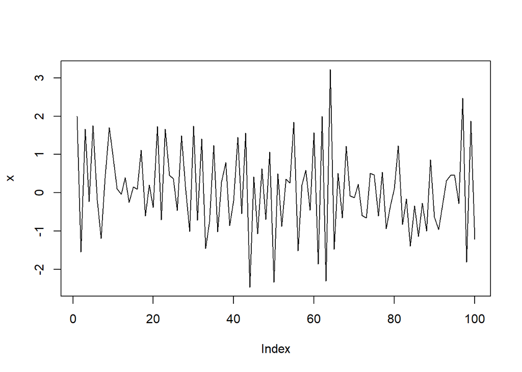

```r
set.seed(4)
w <- rnorm(100)

x <- numeric(100)
x[1] <- 2
for (t in 2:100) {
  x[t]<- -(1/2)*x[t-1] + w[t]

}
plot(x, type = 'l')
```

## 2

Es de termino Autoregresivo de orden 1 y coeficiente -1/2

## 3

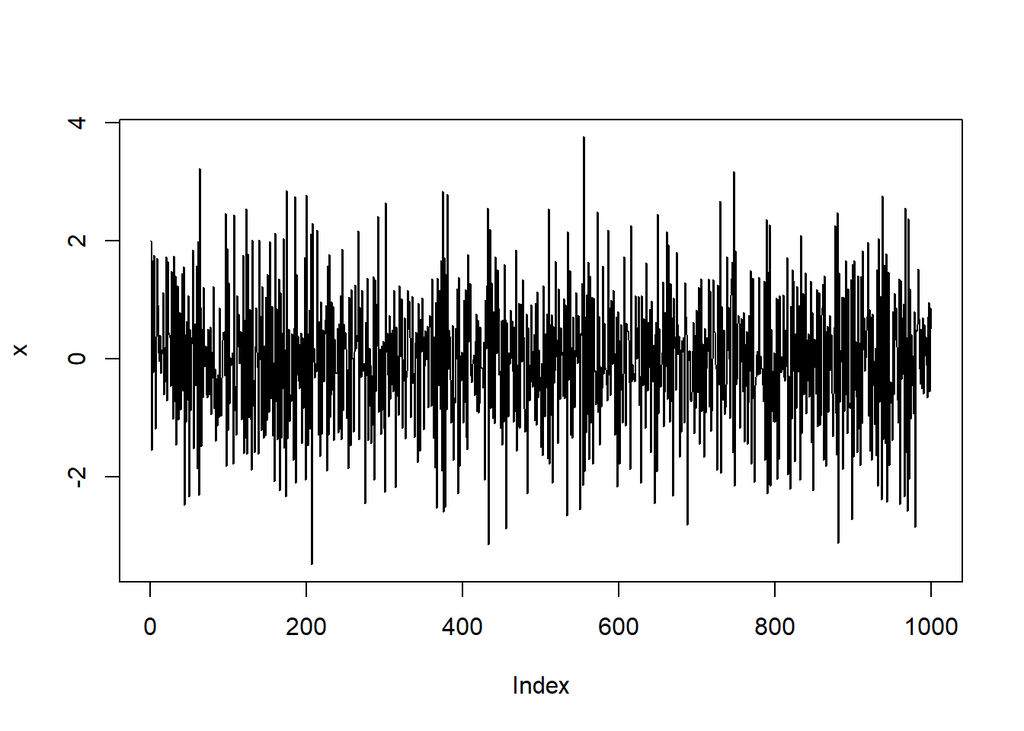

```r
set.seed(4)
w <- rnorm(1000)

x <- numeric(1000)
x[1]<-2
for (t in 2:1000)
  x[t]<- -(1/2)*x[t-1] + w[t]
plot(x, type = 'l')
```

## 4

```r
set.seed(4)
w <- rnorm(1000)

x <- numeric(1000)
x[1]<-2
for (t in 4:100) {
  x[t]<- -(1/2)*x[t-1] + w[t]

}
mean(x)
```

```
## [1] 0.007653135
```

## 5

(-1/2)^(t-1) * 2

## 6

su raiz es -0.5< 1 por tanto convergente

## 7

# E

5. Xt = Xt−1 − Xt−2 + Wt con X1 = 2 y X2 = 4.

## 1

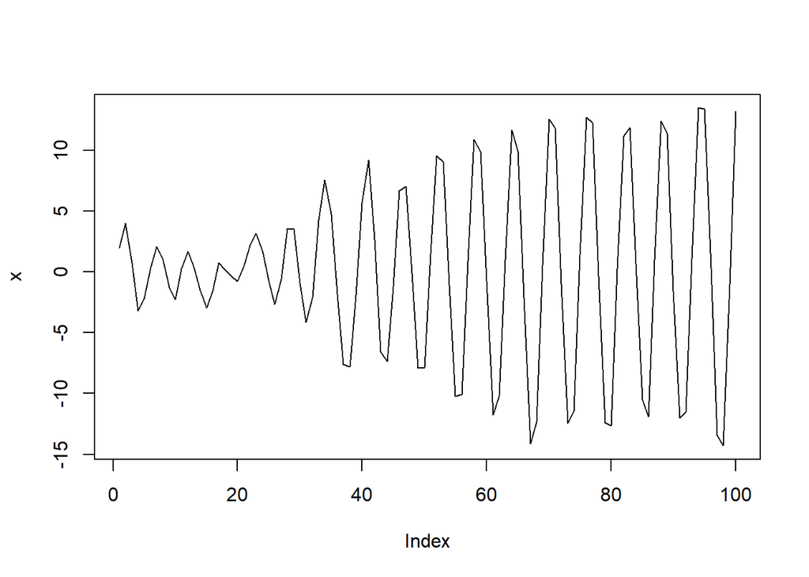

```r
set.seed(5)
w <- rnorm(100)

x <- numeric(100)
x[1]<-2
x[2]<-4
for (t in 3:100) {
  x[t]<- x[t-1] - x[t-2] + w[t]

}
plot(x, type = 'l')
```

## 2

Es de termino Autoregresivo de orden 2

## 3

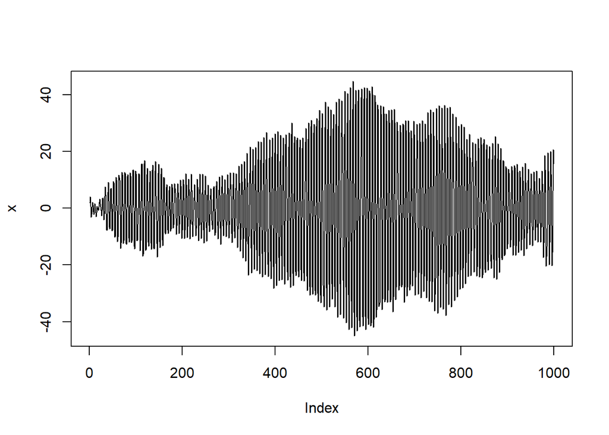

```r
set.seed(5)
w <- rnorm(1000)

x <- numeric(1000)
x[1]<-2
x[2]<-4
for (t in 3:1000)
  x[t]<- x[t-1] - x[t-2] + w[t]
plot(x, type = 'l')
```

## 4

```r
set.seed(5)
w <- rnorm(1000)

x <- numeric(1000)
x[1]<-2
x[2]<-4
for (t in 3:100) {
  x[t]<- x[t-1] - x[t-2] + w[t]

}
mean(x)
```

```
## [1] 0.005597611
```

## 5

## 6

## 7

# F

5. 6. Xt = 1/2Xt−1 −1/2Xt−2 + Wt , con X1 = 1 y X2 = 4.

## 1

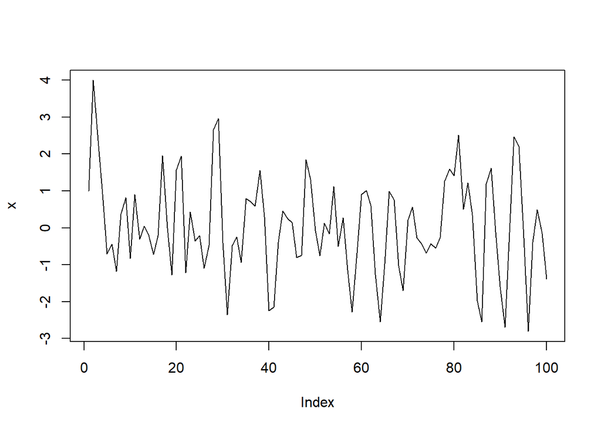

```r
set.seed(6)
w <- rnorm(100)

x <- numeric(100)
x[1]<-1
x[2]<-4

for (t in 3:100) {
  x[t]<- (1/2)*x[t-1] - (1/2)*x[t-2] + w[t]

}
plot(x, type = 'l')
```

## 2

Es de termino Autorgresion de 2do orden

## 3

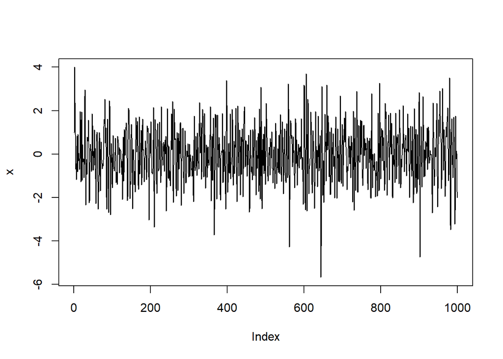

```r
set.seed(6)
w <- rnorm(1000)

x <- numeric(1000)
x[1]<-1
x[2]<-4
for (t in 3:1000)
  x[t]<- (1/2)*x[t-1] - (1/2)*x[t-2] + w[t]
plot(x, type = 'l')
```

## 4

```r
set.seed(6)
w <- rnorm(1000)

x <- numeric(1000)
x[1]<-1
x[2]<-4
for (t in 4:100) {
  x[t]<- (1/2)*x[t-1] - (1/2)*x[t-2] + w[t]

}
mean(x)
```

```
## [1] 0.001397504
```

## 5

## 6

## 7